# Home assignment 02: Data analysis Task 2

This is the second Almaz Murzabekov’s home assignment of Data analysis Task 2

### 2 Assignment on Regression and Classification

```
1. Simple regression. Get a univariate dataset from sources 2.
```

For this task I picked up the prices of the Index of Moscow Exchange (IMOEX) from Moscow Exchange (MOEX); IMOEX is the main ruble-denominated benchmark of the Russian stock market. This datasets contains 9 columns and 192 rows (observations), each row in dataset describes the stock data (like prices, volume, date, etc) for one day from 2019 January 3th till 2019 October 04.

```r
sber_prices = read.csv("data/t2/SBER.csv", header = TRUE, stringsAsFactors = FALSE)
imoex_prices = read.csv("data/t2/IMOEX.csv", header = TRUE, stringsAsFactors = FALSE)

sber = (sber_prices$OPEN - sber_prices$CLOSE) / sber_prices$CLOSE
imoex = (imoex_prices$OPEN - imoex_prices$CLOSE) / imoex_prices$CLOSE

research_dataset <- as.data.frame(
  setNames(
    cbind(sber, imoex),
    c("SBER", "IMOEX"))
  )

summary(research_dataset)
```

```
      sber                imoex
 Min.   :-0.0365493   Min.   :-0.0271142
 1st Qu.:-0.0085589   1st Qu.:-0.0046629
 Median :-0.0003336   Median :-0.0006565
 Mean   :-0.0003456   Mean   :-0.0005457
 3rd Qu.: 0.0077974   3rd Qu.: 0.0037217
 Max.   : 0.0345917   Max.   : 0.0196358
```

##### (a) Build a simple regression model (command lm). Provide the estimates of the model’s parameters. Draw the scatter plot and the regression line.

```r
head(research_dataset)
```

|  | sber | imoex |
| --- | --- | --- |
| 1 | -0.003315685 | -0.002694056 |
| 2 | -0.015707629 | -0.011186370 |
| 3 | 0.002196193 | 0.003381192 |
| 4 | -0.021776650 | -0.007899326 |
| 5 | -0.002287166 | -0.010044574 |
| 6 | 0.001676829 | -0.003219538 |

First of all, we need to split dataset into 2 subset for train and test with 75% propotion for train dataset

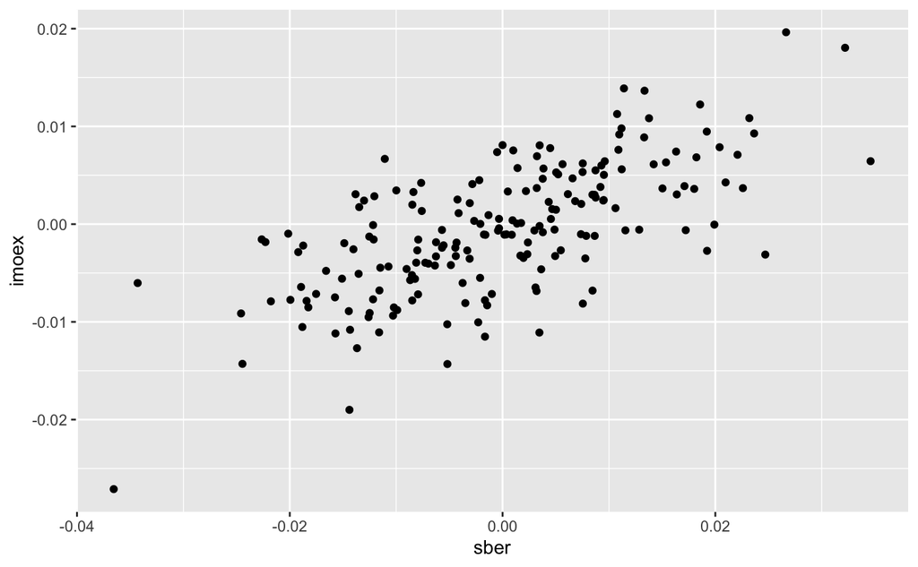

```r
## set the seed to make your partition reproducible
set.seed(123)
smp_size <- floor(0.75 * nrow(research_dataset))
train_ind <- sample(seq_len(nrow(research_dataset)), size = smp_size)

research_dataset_train <- research_dataset[train_ind, ]
research_dataset_test <- research_dataset[-train_ind, ]

simple_regression_model = lm(sber ~ imoex, data = research_dataset_train)

library(ggplot2)
library(tidyverse)
ggplot(data = research_dataset) + geom_point(mapping = aes(x = sber, y = imoex))
```

##### (b) Analyze the summary statistics (command summary()) focusing on:

```
    i. The t-test for the slope. Explain.
    ii. The F-test. Explain.
    iii. R2 coefficient. Explain.
```

```r
summary(simple_regression_model)
```

```
Call:
lm(formula = sber ~ imoex, data = research_dataset_train)

Residuals:
       Min         1Q     Median         3Q        Max
-0.0282423 -0.0050105 -0.0001702  0.0064706  0.0271613

Coefficients:
             Estimate Std. Error t value Pr(>|t|)
(Intercept) 0.0013833  0.0007605   1.819    0.071 .
imoex       1.2347033  0.1224351  10.085   <2e-16 ***
---
Signif. codes:  0 ‘***’ 0.001 ‘**’ 0.01 ‘*’ 0.05 ‘.’ 0.1 ‘ ’ 1

Residual standard error: 0.009093 on 142 degrees of freedom
Multiple R-squared:  0.4173,    Adjusted R-squared:  0.4132
F-statistic: 101.7 on 1 and 142 DF,  p-value: < 2.2e-16
```

2. The F-test. Explain.

Result of the summary: F-statistic: 101.7 on 1 and 142 DF, p-value: < 2.2e-16

The p-value is less than the significance level 5%. Sample data provides sufficient evidence to conclude that the regression model fits the data better than the model with no independent variables.

3. R2 coefficient. Explain.

Multiple R-squared: 0.4173, Adjusted R-squared: 0.4132

The percentage of the response variable variation that is explained by a linear model (R-squared = Explained variation / Total variation)

```
(c) Plot the residuals against fitted values and comment on the model’s adequacy. Examine the qq-plot for the residuals.
```

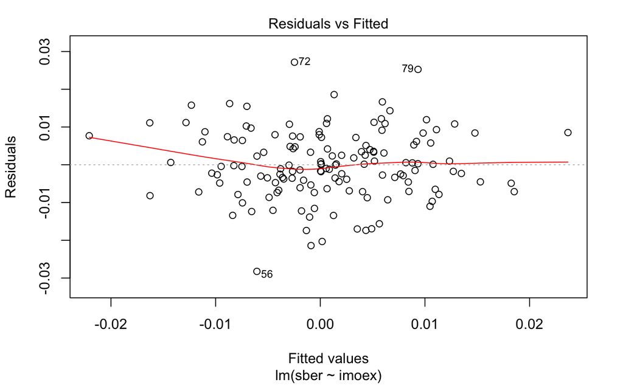

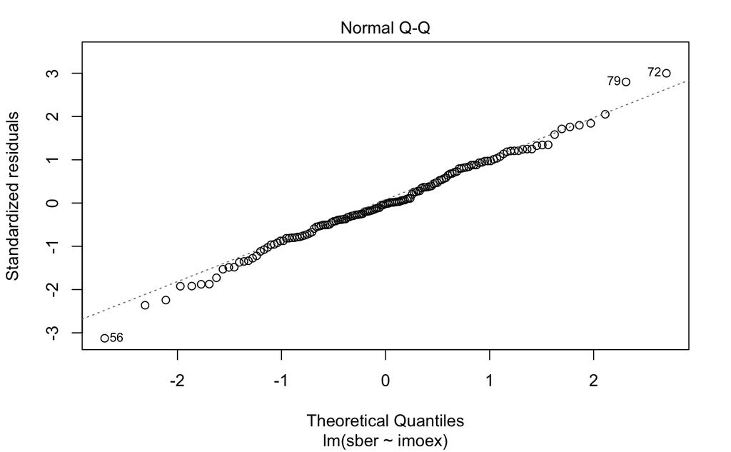

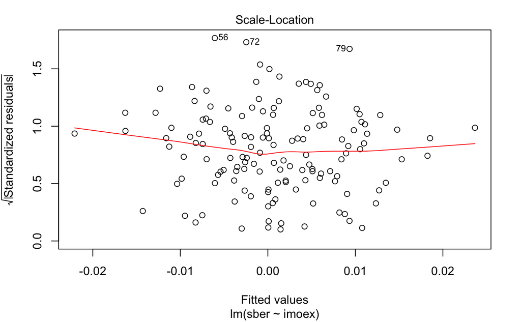

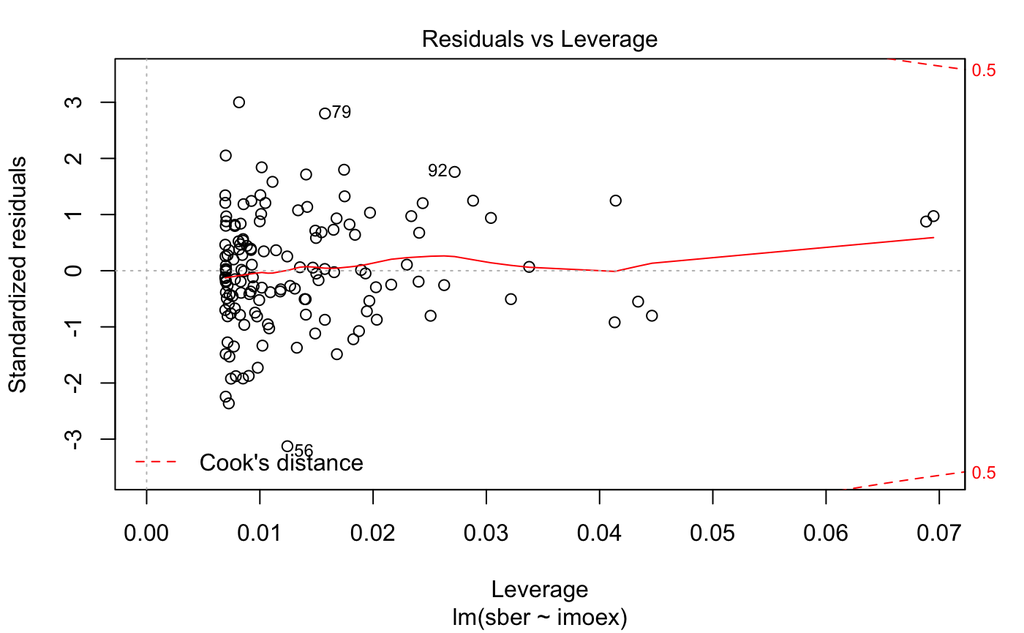

```r
plot(simple_regression_model)
```

```
(d) Make predictions for several new values of the independent variable. For each predicted value, compute and plot the confidence intervals for the mean and single value.
```

```r
head(research_dataset_test[, "sber"])
```

```
[1] -0.015707629  0.002196193 -0.008115286 -0.018422568 -0.008482564 -0.018257572
```

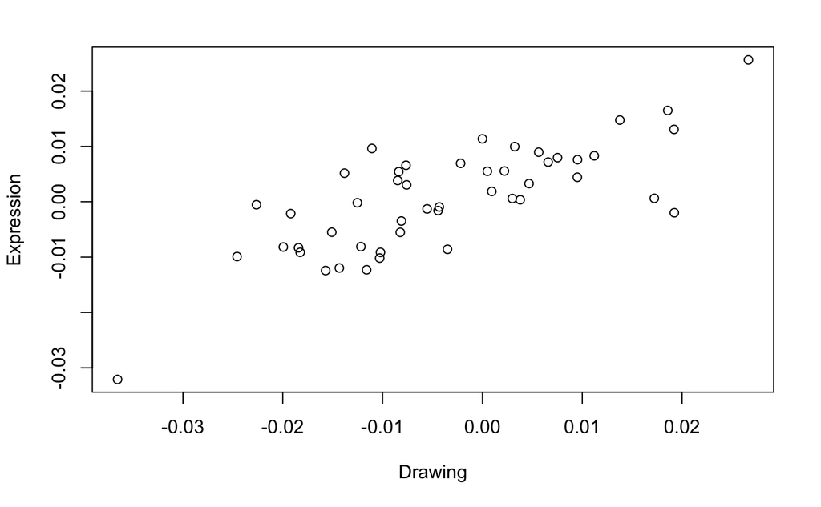

```r
prediction_for_test = predict(simple_regression_model, new = research_dataset_test, interval = "pred")
conf_interval_for_test = predict(simple_regression_model, new = research_dataset_test, interval = "confidence")

plot(research_dataset_test$sber, prediction_for_test[,1], col="black", xlab = "Drawing", ylab = "Expression")
```

### REFERENCES

[1] https://r-analytics.blogspot.com/2013/02/blog-post.html

2. Multivariate regression. Get a multivariate dataset (at least 3 variables) from 3.

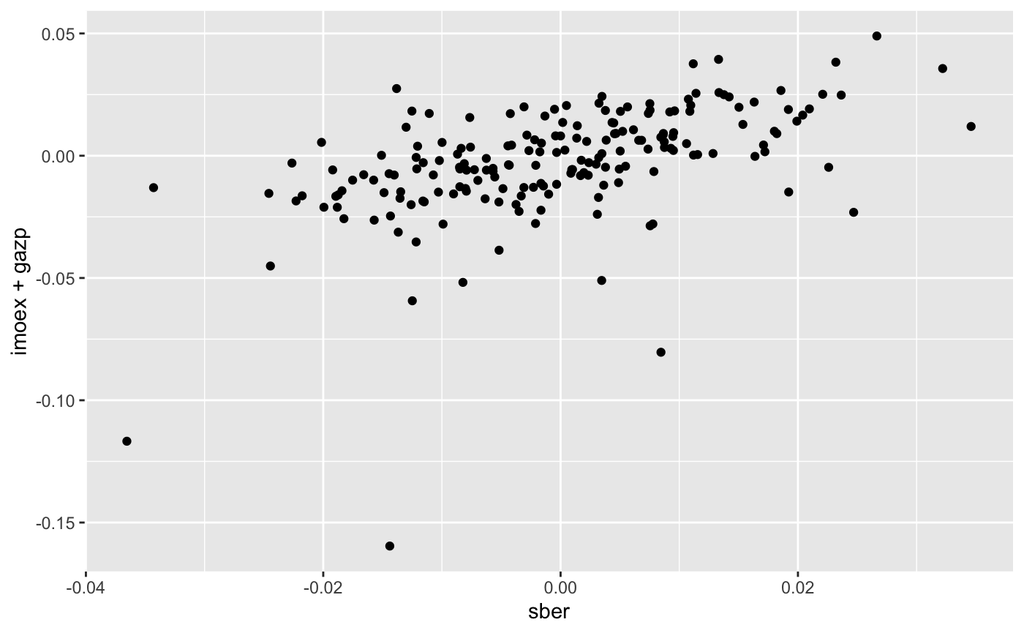

```r
gazp_prices = read.csv("data/t2/GAZP.csv", header = TRUE, stringsAsFactors = FALSE)

gazp = (gazp_prices$OPEN - gazp_prices$CLOSE) / gazp_prices$CLOSE

research_dataset2 <- as.data.frame(
  setNames(
    cbind(sber, imoex, gazp),
    c("SBER", "IMOEX", "GAZP"))
  )

smp_size <- floor(0.75 * nrow(research_dataset2))
mr_train_ind <- sample(seq_len(nrow(research_dataset2)), size = smp_size)

mr_research_dataset_train <- research_dataset2[mr_train_ind, ]
mr_research_dataset_test <- research_dataset2[-mr_train_ind, ]



ggplot(data = research_dataset2) + geom_point(mapping = aes(x = sber, y = imoex + gazp))
```

```
(a) Choose the response and explanatory variables.
```

Response variable is delta price of SBERBANK Explanatory variables are delta prices of Moscow exchange index (IMOEX) and deltas of GAZP stock

```
(b) Build a multivariate linear model (command lm). Provide the estimates of the model’s parameters.
```

```
(c) Analyze the summary statistics (command summary()) with the emphasis on:
```

```r
summary(multivariate_regression_model)
```

```
Call:
lm(formula = sber ~ imoex + gazp, data = mr_research_dataset_train)

Residuals:
       Min         1Q     Median         3Q        Max
-0.0263238 -0.0039094  0.0002311  0.0053796  0.0249857

Coefficients:
              Estimate Std. Error t value Pr(>|t|)
(Intercept)  0.0004499  0.0007435   0.605    0.546
imoex        1.4847618  0.1494877   9.932   <2e-16 ***
gazp        -0.0742450  0.0520966  -1.425    0.156
---
Signif. codes:  0 ‘***’ 0.001 ‘**’ 0.01 ‘*’ 0.05 ‘.’ 0.1 ‘ ’ 1

Residual standard error: 0.008837 on 141 degrees of freedom
Multiple R-squared:  0.5235,    Adjusted R-squared:  0.5167
F-statistic: 77.45 on 2 and 141 DF,  p-value: < 2.2e-16
```

Result of the summary: F-statistic: 77.45 on 2 and 141 DF, p-value: < 2.2e-16

The p-value is less than the significance level 5%. Sample data provides sufficient evidence to conclude that the regression model fits the data better than the model with no independent variables.

3. R2 coefficient. Explain.

Multiple R-squared: 0.5235, Adjusted R-squared: 0.5167 The percentage of the response variable variation that is explained by a linear model (R-squared = Explained variation / Total variation)

R-squared = 52.35% indicates that the model explains most of the variability of the response data around its mean. The prediction pover of this model is 52% it’s slightly greather than simple linear regression model (42%)

```
(d) Plot the residuals against fitted values and comment on the model’s adequacy.
```

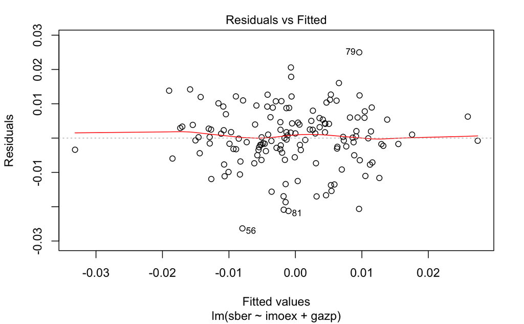

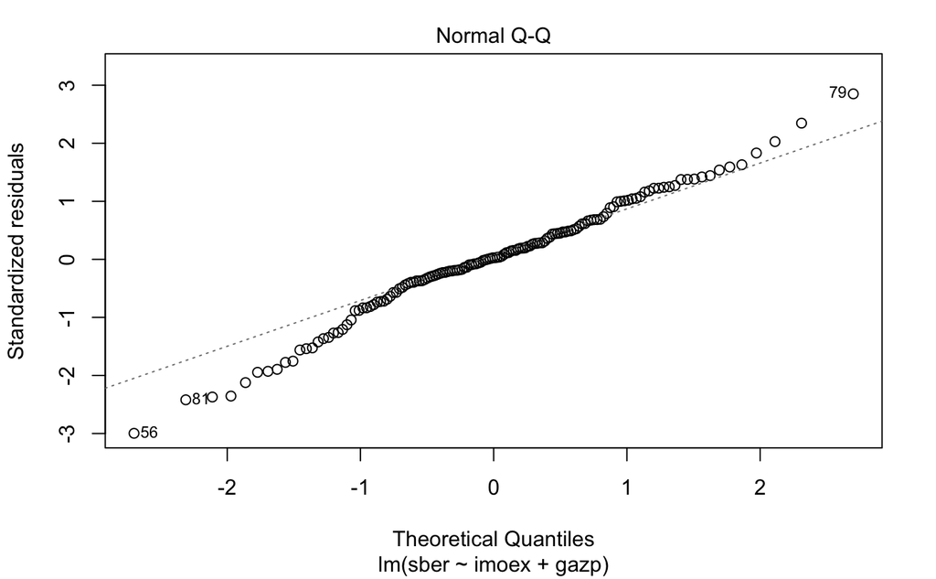

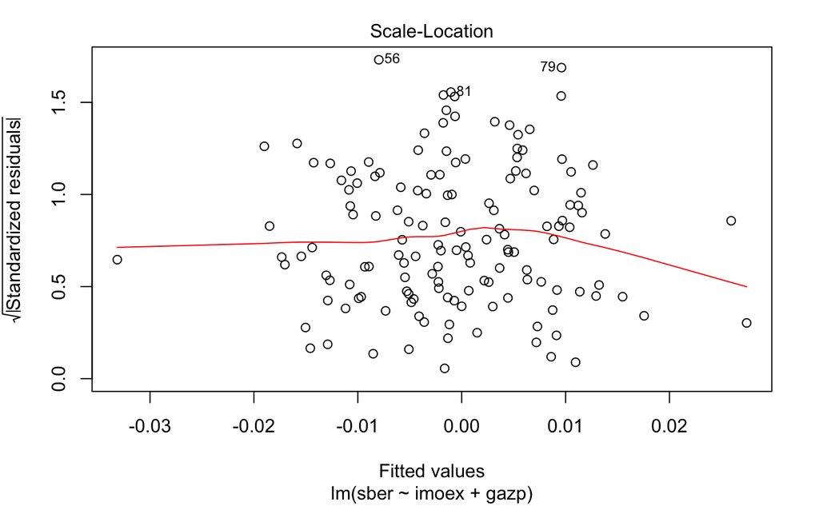

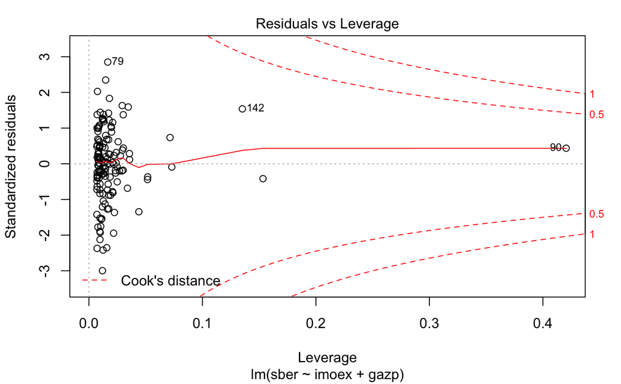

```
(e) Play with your model by adding or removing the explanatory variables. Alternatively, add a non-linear term(s) to your model:
    i. Choose the best one by the AIC criterion (command stepAIC), see p. 295 of [1].
    ii. For each model, watch the value of the adjusted R2. Explain.
```

3. Logistic regression. Get a binary response regression dataset from 2 or 3. Briefly describe the data.
   1. Build a logistic regression model (command glm). Comment on the significance of the coefficients.

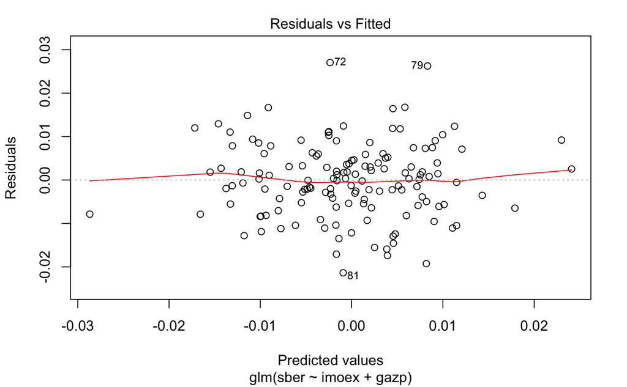

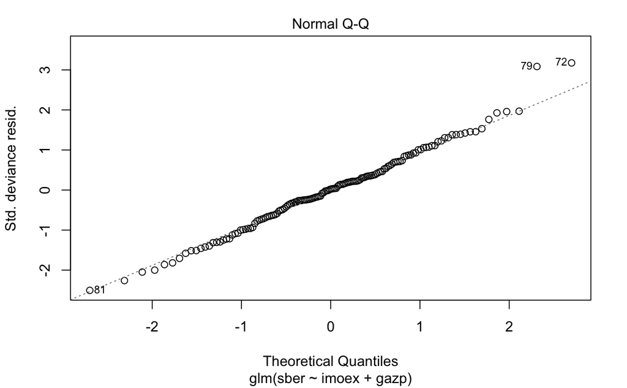

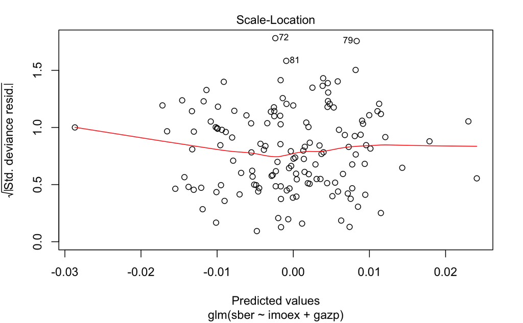

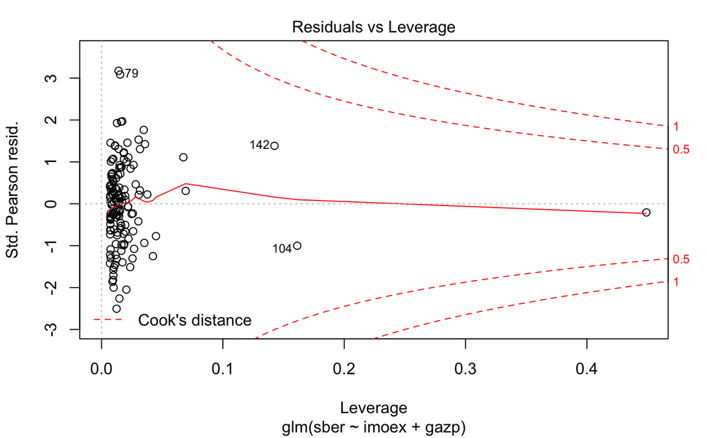

```
(b) Use stepAIC command to select the best model.
```

```r
stepAIC(model_lr)
```

```
Start:  AIC=-956.73
sber ~ imoex + gazp

        Df Deviance     AIC
<none>     0.010383 -956.73
- gazp   1 0.010603 -955.71
- imoex  1 0.016889 -888.68

Call:  glm(formula = sber ~ imoex + gazp, data = mr_research_dataset_train)

Coefficients:
(Intercept)        imoex         gazp
  7.155e-05    1.358e+00   -9.004e-02

Degrees of Freedom: 143 Total (i.e. Null);  141 Residual
Null Deviance:      0.02006
Residual Deviance: 0.01038  AIC: -956.7
```

```
(c) Make a prediction based on the entire dataset. State the threshold of acceptance. Compare the forecast with the actual observations. Comment on the results.
```

```
(d) Divide the entire set into training and test subsets. Rebuild the model using only the training subset. Make predictions for the test subset. Comment.
```

4. Discriminant analysis. Use the same dataset as for the logistic regression.
   1. Conduct the linear discriminant analysis (command lda, package MASS) using training and test subsets. Compare the forecast with the actual observations. Comment on the results.

```r
print(model_LDA)
```

[output not shown]

```
(b) Conduct the quadratic discriminant analysis (command qda). Comment.
```

5. The KNN classifier. Use the same dataset as for the logistic regression and discriminant analysis.
   1. Conduct the KNN classification (command knn(), package class) using training and test subsets. Compare the forecast with the actual observations. Comment on the results.

```r
library(class)

target_category = mr_research_dataset_train[, "sber"]
test_category = mr_research_dataset_test[, "sber"]

set.seed(231)
knn_predicts = knn(mr_research_dataset_train, mr_research_dataset_test, cl = target_category, k = 13)

test_category[1:10]
```

```
 [1] -0.003315685  0.002196193  0.001676829 -0.003080808 -0.013017987  0.008447169 -0.008482564 -0.018257572 -0.012528683  0.003480278
```

```r
knn_predicts[1:10]
```

```
 [1] -0.00697093252663424 0.00238280713009215  0.00319331859493971  -0.0110691144708424  -0.00837888699704277 0.00946185688941463  -0.00569105691056913
 [8] -0.0135312090790048  -0.0102140945584299  -0.00266655726944526
144 Levels: -0.0365492811002291 -0.0342990654205608 -0.0245824655967985 -0.0244510334751407 -0.0226373626373627 ... 0.0345917471466198
```

```
(b) Play with the number of nearest neighbors K.
```

```r
set.seed(231)
knn_predicts = knn(mr_research_dataset_train, mr_research_dataset_test, cl = target_category, k = 76)

test_category[1:10]
```

```
 [1] -0.003315685  0.002196193  0.001676829 -0.003080808 -0.013017987  0.008447169 -0.008482564 -0.018257572 -0.012528683  0.003480278
```

```r
knn_predicts[1:10]
```

```
 [1] 0.00093896713615023  -0.00868496517820567 0.00363207547169816  -0.0201457351050151  -0.0043241735248989  0.00466778805719085  -0.0107244995233556
 [8] -0.00350053537599866 -0.0043241735248989  -0.00569476082004556
144 Levels: -0.0365492811002291 -0.0342990654205608 -0.0245824655967985 -0.0244510334751407 -0.0226373626373627 ... 0.0345917471466198
```

```r
set.seed(231)
knn_predicts = knn(mr_research_dataset_train, mr_research_dataset_test, cl = target_category, k = 3)

test_category[1:10]
```

```
 [1] -0.003315685  0.002196193  0.001676829 -0.003080808 -0.013017987  0.008447169 -0.008482564 -0.018257572 -0.012528683  0.003480278
```

```r
knn_predicts[1:10]
```

```
 [1] -0.00485908649173955 0.00522700764611853  0.00232931726907636  0.000176258041773121 -0.00998781973203416 0.00682593856655293  -0.00569476082004556
 [8] -0.0143356488650944  -0.00765265023360724 0.000359874044084499
144 Levels: -0.0365492811002291 -0.0342990654205608 -0.0245824655967985 -0.0244510334751407 -0.0226373626373627 ... 0.0345917471466198
```

6. Compare the quality of classification obtained by algorithms 3-5 for the test subset.

For tasks 3-5, see [3], Chapter 4.